# Práctica Análisis Exploratorio de Datos: Bike Sharing

# 4 Proceso de exploración

En este apartado realizaremos la carga de datos, su limpieza y procesamiento.

```r
# Cargamos la librería tidyverse
library(tidyverse)
# Cargamos el dataset por horas
datos_bikes <- read.csv("bike+sharing+dataset/hour.csv")

# 1. Comprobamos dimensiones y valores nulos
dim(datos_bikes)
```

```
[1] 17379    17
```

```r
sum(is.na(datos_bikes))
```

```
[1] 0
```

```r
# Observamos que no hay valores nulos 'NA' en el dataset

# 2. Revisamos la coherencia interna
# Verificamos si la suma de casual + registered siempre da cnt
sum(datos_bikes$casual + datos_bikes$registered != datos_bikes$cnt)
```

```
[1] 0
```

```r
# Observamos también que la variable 'cnt' es exactamente la suma de 'casual' y 'registered' en el     100% de los registros, asegurando así la integridad de los datos.

# 3. Transformación de tipos de datos
# Convertimos variables númericas que en realidad son categorías a factores
datos_bikes <- datos_bikes |>
  mutate(
    season = factor(season, levels = 1:4, labels = c("Invierno", "Primavera", "Verano", "Otoño")),
    holiday = factor(holiday, levels = c(0,1), labels = c("No", "Sí")),
    workingday = factor( workingday, levels = c(0,1), labels = c("No", "Sí")),
    weathersit = factor(weathersit, levels = 1:4)
)

# Resumen estadístico
summary(datos_bikes)
```

```
    instant            dteday            season           yr
 Min.   :    1   Length   :17379   Invierno :4242   Min.   :0.0000
 1st Qu.: 4346   N.unique :  731   Primavera:4409   1st Qu.:0.0000
 Median : 8690   N.blank  :    0   Verano   :4496   Median :1.0000
 Mean   : 8690   Min.nchar:   10   Otoño    :4232   Mean   :0.5026
 3rd Qu.:13034   Max.nchar:   10                    3rd Qu.:1.0000
 Max.   :17379                                      Max.   :1.0000
      mnth              hr        holiday       weekday      workingday
 Min.   : 1.000   Min.   : 0.00   No:16879   Min.   :0.000   No: 5514
 1st Qu.: 4.000   1st Qu.: 6.00   Sí:  500   1st Qu.:1.000   Sí:11865
 Median : 7.000   Median :12.00              Median :3.000
 Mean   : 6.538   Mean   :11.55              Mean   :3.004
 3rd Qu.:10.000   3rd Qu.:18.00              3rd Qu.:5.000
 Max.   :12.000   Max.   :23.00              Max.   :6.000
 weathersit      temp           atemp             hum           windspeed
 1:11413    Min.   :0.020   Min.   :0.0000   Min.   :0.0000   Min.   :0.0000
 2: 4544    1st Qu.:0.340   1st Qu.:0.3333   1st Qu.:0.4800   1st Qu.:0.1045
 3: 1419    Median :0.500   Median :0.4848   Median :0.6300   Median :0.1940
 4:    3    Mean   :0.497   Mean   :0.4758   Mean   :0.6272   Mean   :0.1901
            3rd Qu.:0.660   3rd Qu.:0.6212   3rd Qu.:0.7800   3rd Qu.:0.2537
            Max.   :1.000   Max.   :1.0000   Max.   :1.0000   Max.   :0.8507
     casual         registered         cnt
 Min.   :  0.00   Min.   :  0.0   Min.   :  1.0
 1st Qu.:  4.00   1st Qu.: 34.0   1st Qu.: 40.0
 Median : 17.00   Median :115.0   Median :142.0
 Mean   : 35.68   Mean   :153.8   Mean   :189.5
 3rd Qu.: 48.00   3rd Qu.:220.0   3rd Qu.:281.0
 Max.   :367.00   Max.   :886.0   Max.   :977.0
```

## 4.1 Análisis Univariante: Distribución de la demanda

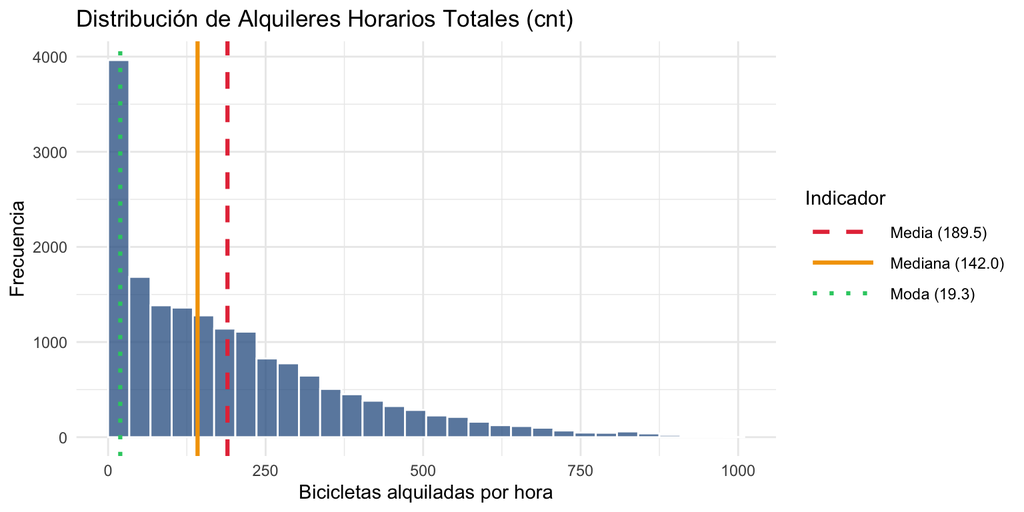

```r
# Función para calcular la moda (pico de la densidad)
calcular_moda <- function(x) {
  d <- density(x, na.rm = TRUE)
  d$x[which.max(d$y)]
}

media   <- mean(datos_bikes$cnt, na.rm = TRUE)
mediana <- median(datos_bikes$cnt, na.rm = TRUE)
moda    <- calcular_moda(datos_bikes$cnt)

indicadores <- data.frame(
  estadistico = factor(
    c("Media", "Mediana", "Moda"),
    levels = c("Media", "Mediana", "Moda")
  ),
  valor = c(media, mediana, moda)
)

etiquetas <- c(
  sprintf("Media (%.1f)", media),
  sprintf("Mediana (%.1f)", mediana),
  sprintf("Moda (%.1f)", moda)
)

ggplot(datos_bikes, aes(x = cnt)) +
  geom_histogram(
    bins = 30, boundary = 0, closed = "left",
    fill = "#2b5c8f", color = "white", alpha = 0.75
  ) +
  geom_vline(
    data = indicadores,
    aes(xintercept = valor, color = estadistico, linetype = estadistico),
    linewidth = 1.1,
    key_glyph = "path"
  ) +
  scale_color_manual(
    name = "Indicador",
    values = c("Media" = "#e63946", "Mediana" = "#f4a300", "Moda" = "#2ecc71"),
    labels = etiquetas
  ) +
  scale_linetype_manual(
    name = "Indicador",
    values = c("Media" = "dashed", "Mediana" = "solid", "Moda" = "dotted"),
    labels = etiquetas
  ) +
  labs(
    title = "Distribución de Alquileres Horarios Totales (cnt)",
    x = "Bicicletas alquiladas por hora",
    y = "Frecuencia"
  ) +
  theme_minimal() +
  theme(
    legend.position = "right",
    legend.key.width = unit(1.5, "cm")
  )
```

**Interpretación:** La demanda presenta una fuerte asimetría positiva, como muestra la relación moda (19,3) < mediana (142,0) < media (189,5): la mayoría de las horas registran pocos alquileres, mientras que unas pocas concentran unos valores muy elevados que desplazan la media hacia la derecha. Por ello, la mediana resulta más representativa de la demanda típica.